# Homework #1

Hugo Lhuillier

26/02/2018

## Exercice 1: loading data

For the exercices below, we will use the data contained in `inflammation-02.csv`, in the `data` folder that we used in class. What are the commands needed to move to the directory that contains `inflammation-02.csv`, and to load the data in a data frame.

**For all the questions, please write your answer is the box below.**

```r
setwd("/Users/hugolhuillier/Dropbox/Teaching/intro-prog/2017-2018/4-8-r/data/")
d = read.csv(file = "inflammation-02.csv", header = FALSE)
```

## Exercice 2: insights on the data

`inflammation-02.csv` is also a panel data. Each column corresponds to a particular day, while each row corresponds to a particular patient. Each data point is thus the inflammation per day per patient.

Given this information, print all the data points of the last three patients. (hint: remember the `head` command? that’s close)

Additionally, print some **summary** statistics on the first 7 days of treatment, for all the patients.

Remember: if the output of a function is not allocated to a variable, then it will be printed in the console.

```r
tail(d,n=3L)
```

```
##    V1 V2 V3 V4 V5 V6 V7 V8 V9 V10 V11 V12 V13 V14 V15 V16 V17 V18 V19 V20
## 58  0  0  2  0  4  3  5  5  6   9   4   5   4   3  10   3   7  11  12  10
## 59  0  0  0  3  3  1  5  7  7   7   6   8   7   6  10  14   6  12   5  15
## 60  0  1  2  0  4  5  6  6  2   5  10  10   3   7  13   9   5  16   6  18
##    V21 V22 V23 V24 V25 V26 V27 V28 V29 V30 V31 V32 V33 V34 V35 V36 V37 V38
## 58  19  16  17  14  16   9  12   5  10  11   6   7   7   3   3   1   1   0
## 59  20  18  14  17  14  11  13  10   9   5   5   5   5   7   1   5   3   2
## 60  15  10  13  11  12  15  10  12   3   8   8   7   5   6   2   5   2   3
##    V39 V40
## 58   2   0
## 59   2   0
## 60   2   0
```

```r
summary(d[,1:7])
```

```
##        V1          V2            V3               V4
##  Min.   :0   Min.   :0.0   Min.   :0.0000   Min.   :0.000
##  1st Qu.:0   1st Qu.:0.0   1st Qu.:0.0000   1st Qu.:1.000
##  Median :0   Median :0.5   Median :1.0000   Median :2.000
##  Mean   :0   Mean   :0.5   Mean   :0.9333   Mean   :1.583
##  3rd Qu.:0   3rd Qu.:1.0   3rd Qu.:2.0000   3rd Qu.:2.000
##  Max.   :0   Max.   :1.0   Max.   :2.0000   Max.   :3.000
##        V5              V6              V7
##  Min.   :1.000   Min.   :1.000   Min.   :1.000
##  1st Qu.:2.000   1st Qu.:1.000   1st Qu.:2.000
##  Median :2.500   Median :2.000   Median :4.000
##  Mean   :2.633   Mean   :2.667   Mean   :3.583
##  3rd Qu.:4.000   3rd Qu.:4.000   3rd Qu.:5.000
##  Max.   :4.000   Max.   :5.000   Max.   :6.000
```

## Exercice 3: cleaning data

Suppose there was something wrong with the data collection on the first five days of treatment, for every second patient (#2, 4, 6, etc.), which resulted in the measurements being twice as large as they should be.

To solve this problem:

1. Write a vector containing which patient was affected? (you may want to type `help(seq)` in the command line)
2. Create a new data frame in which you halve the first five days’ values in **only** those patients (remember how to subset a data frame? that’s no more complicated than that!)
3. Print out the corrected data frame to check that your code has fixed the problem

```r
patients <- seq(2,60,2)
days     <- c(1:5)
d2       <- d
d2[patients, days] <- d2[patients, days] / 2
d2
```

```
##    V1  V2  V3  V4  V5 V6 V7 V8 V9 V10 V11 V12 V13 V14 V15 V16 V17 V18 V19
## 1   0 0.0 0.0 1.0 3.0  4  6  5  2   7   7   8   6  11   5   6  10   4   5
## 2   0 0.0 1.0 1.0 2.0  2  1  7  5   7   3   6  10   5   5  14  14   9  11
## 3   0 1.0 2.0 3.0 2.0  1  4  1  8   7   4   5  10   3  11   5  11   8  18
## 4   0 0.0 0.0 0.0 0.5  2  4  7  3   5   8   7   5  13  10   7  11   8  18
## 5   0 1.0 0.0 2.0 1.0  2  3  6  5   2   9   3   5  12   9   5   8  11   9
## 6   0 0.0 0.5 1.5 2.0  4  2  2  6   3   2   9   4  11  12   8   6   8   8
## 7   0 1.0 0.0 3.0 2.0  3  2  2  4   6   4  11  11   8   3   9  11   7  12
## 8   0 0.5 1.0 0.5 2.0  1  2  7  2   2   8   9   5   6  12  12   6  14   6
## 9   0 0.0 1.0 2.0 2.0  1  4  2  7   4  10   6   4   3   6   5   8  13   8
## 10  0 0.5 0.5 0.5 2.0  2  1  3  5   3   2   3  11   3   4   5  14   4   5
## 11  0 1.0 0.0 0.0 2.0  3  5  2  5   8   4   7   7   8   5   5   8  15  14
## 12  0 0.5 1.0 1.5 1.0  5  6  4  2   4   6   9   6   9   6   6  14  11   6
## 13  0 0.0 0.0 1.0 4.0  1  4  1  7   7   8   7   7   4   9   3   8  17  17
## 14  0 0.0 1.0 0.5 0.5  4  5  7  8   5   5   3   6   9   7   8  10  10  13
```

[output cut: 168 more lines]

## Exercice 4: computing statistics

Compute these statistics on the original data, not the one modified in exercice 3.

```r
apply(d[,1:10], 2, median)
```

```
##  V1  V2  V3  V4  V5  V6  V7  V8  V9 V10
## 0.0 0.5 1.0 2.0 2.5 2.0 4.0 4.0 4.5 6.0
```

```r
apply(d[, seq(1, 40, by = 2)], 2, max)
```

```
##  V1  V3  V5  V7  V9 V11 V13 V15 V17 V19 V21 V23 V25 V27 V29 V31 V33 V35
##   0   2   4   6   8  10  12  14  16  18  20  18  16  14  12  10   8   6
## V37 V39
##   4   2
```

```r
rowMeans(d[1:5,])
```

```
##     1     2     3     4     5
## 6.350 5.700 5.900 5.325 6.050
```

## Exercice 5: plotting

Plot the minimum inflammation per day over the whole period.

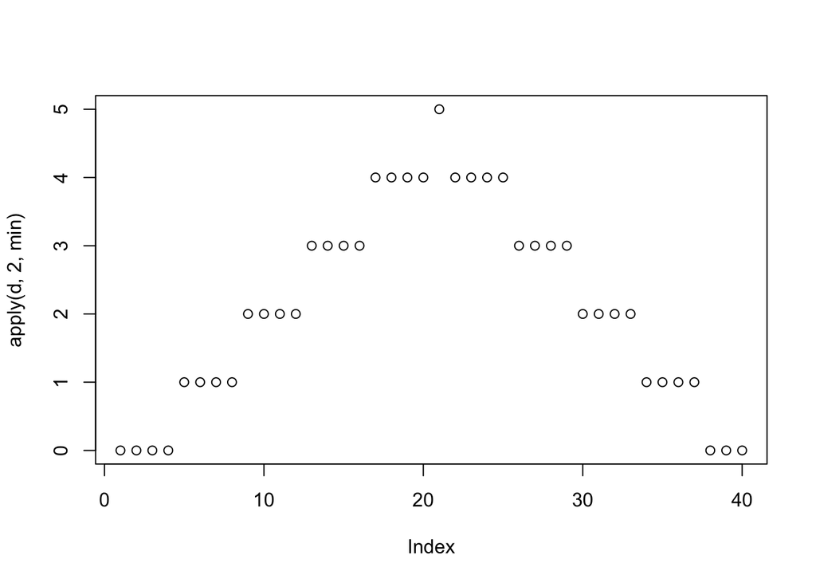

```r
plot(apply(d, 2, min))
```

For fun, you can also try the `boxplot` command. (once again, you may want to check `help(boxplot)` if the first place).

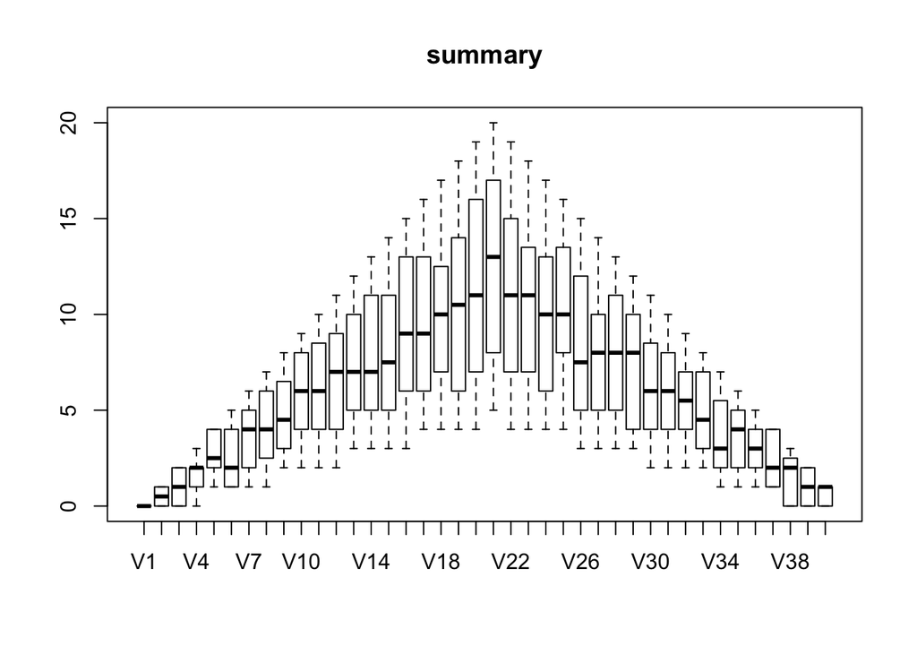

```r
boxplot(d, main = "summary")
```